# Escape from Boxland

## 4 Simplexes

Simplexes are one of the simplest objects to create and view. A $p$-D simplex is a shape that is created in the $(p+1)$th dimension with vertices corresponding to the coordinate axes. The simplex vertices are then projected, using a Helmert matrix, into the $p$-dimensional space in which it exists.

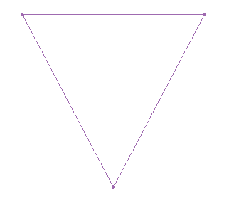

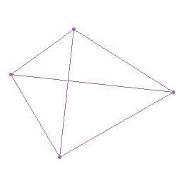

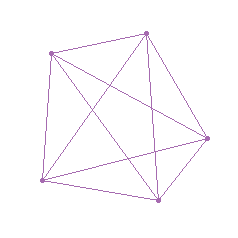

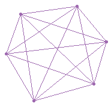

Figure 7: Wireframe simplexes: 2-D, 3-D, 4-D, 5-D.

For example, a 2-D simplex has unprojected 3-D vertices at (1,0,0), (0,1,0), (0,0,1), which are reduced by the Helmert transformation to points in a 2-D equilateral triangle, (0.7071,0.4082), (-0.7071,0.4082), (0.0000, -0.8165).

```r
helmert <- function(d) {
  helmert_mat <- matrix(NA, nrow = d, ncol = d)
  helmert_mat[1, ] <- rep(1 / sqrt(d), d)
  for (i in 1:(d - 1)) {
    helmert_mat[i + 1, ] <- c(
      rep(1 / sqrt(i * (i + 1)), i),
      -i / sqrt(i * (i + 1)),
      rep(0, d - i - 1)
    )
  }
  helmert_mat
}

simplex <- function(p) {
  x <- diag(p)
  # center simplex
  x <- x - matrix(1 / p, p, p)
  hm <- helmert(p)
  final <- (x %*% t(hm))[, -1]
  final
}
```

The wire frame for a simplex connects every point to every other point, and can be computed in just two lines of code, following method 2 of the cube vertices. `simplex_wires` makes a list of all pairs of verticies and then removes the edges that connect a vertex to itself.

```r
simplex_wires <- function(simplex) {
  wires <- do.call(
    expand.grid,
    list(
      c(1:nrow(simplex)),
      c(1:nrow(simplex))
    )
  )
  wires[!wires[,1] == wires[,2],]
}
```

## 5 Polyhedra

A polyhedron is a three dimensional object that contains straight edges and has flat faces. Our polyhedra data comes from George W. Hart’s website (Hart 2000). Hart’s website contains an extensive collection of polyhedra, ranging from Platonic Solids to Stellations of the Rhombic Triacontahedron. In our data sets, we used the information from Platonic Solids, Kepler-Poinsot Polyhedra, Archimedean Polyhedra and its duals, Prisms. The data was reformatted from VRML into XML. The vertices and wire frames from separate files were compiled into tables. Some reformatting of edges was also necessary.

## 6 Surfaces and curves

[figure not shown]

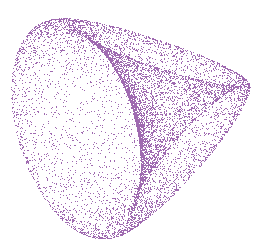

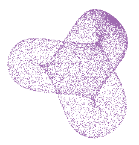

Figure 8: Mobius strip, Steiner’s roman surface, and Boy’s surface.

## 7 Polytopes

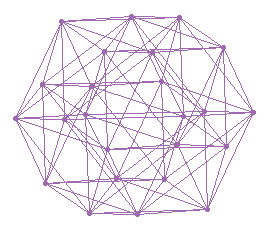

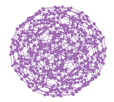

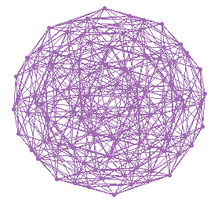

Figure 9: 24-Cell, 120-Cell, and 600-Cell.

## 8 Tori

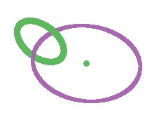

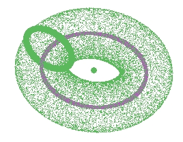

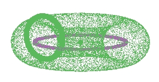

[figure not shown]

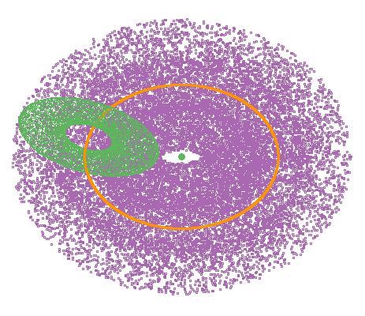

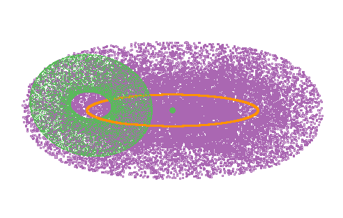

Figure 10: Generating a torus: 2-D to 3-D (top row), and 3-D to 4-D (bottom row).

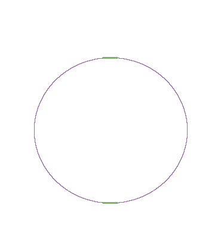

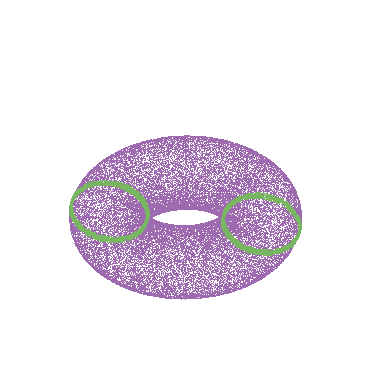

[figure not shown]

Figure 11: 2-D, 3-D, and 4-D tori with features highlighted.

### 8.1 Ring torus

A ring torus has a hole in the center of the object and is generated recursively. A 2-D circle forms the base of the torus, which is defined by:

$$\begin{aligned}
&&X_1: cos(\theta_1) * r_1\\
&&X_2: sin(\theta_1) * r_1
\end{aligned}$$

using one radius and one angle. The 3-D torus is defined by:

$$\begin{aligned}
&&X_1: cos(\theta_1) * (r_1 + cos(\theta_2) * r_2)\\
&&X_2: sin(\theta_1) * (r_1 + cos(\theta_2) * r_2)\\
&&X_3: sin(\theta_2) * r_2\\
&&r_1 > r_2
\end{aligned}$$

Notice that 3-D torus builds from the 2-D: $r_1$ is replaced by ($r_1 + cos(\theta_2)r_2$). The 3-D torus has four parameters: two angles and two radii. The third dimension is formed entirely by the additional angle and radius. A 4-D torus will be generated with the same pattern as the 3-D torus: a new dimension will be added and material will be inserted recursively into the formulas:

$$\begin{aligned}
&&X_1: cos(\theta_1) * (r_1 + cos(\theta_2) * (r_2 + cos(\theta_3) * r_3))\\
&&X_2: sin(\theta_1) * (r_1 + cos(\theta_2) * (r_2 + cos(\theta_3) * r_3))\\
&&X_3: sin(\theta_2) * (r_2 + cos(\theta_3) * r_3)\\
&&X_4: sin(\theta_3) * r_3\\
&&r_1 > r_2 > r_3
\end{aligned}$$

The steps to building a higher-dimensional torus are:

1. add a new dimension that equals $sin(\theta_i) * r_i$.
2. in all other dimensions, replace $r_{i - 1}$ with $r_{i - 1} + cos(\theta_i) * r_i$.
3. repeat.

However, these steps are not easy to recurse. Replacing values in a formula after it has been realized is not simple. By rearranging the formulas, a better method to recurse is achieved:

$$\begin{aligned}
&&X_1: ((cos(\theta_3) * r_3 + r_2) * (cos(\theta_2) + r_1) * cos(\theta_1)\\
&&X_2: ((cos(\theta_3) * r_3 + r_2) * (cos(\theta_2) + r_1) * sin(\theta_1)\\
&&X_3: (cos(\theta_3) * r_3 + r_2) * sin(\theta_2)\\
&&X_4: sin(\theta_3) * r_3\\
&&r_1 > r_2 > r_3
\end{aligned}$$

The first step of the recursion, starting from the last dimension, is given as follows:

$$\begin{aligned}
&&X_1: cos(\theta_3) * r_3\\
&&X_2: cos(\theta_3) * r_3\\
&&X_3: cos(\theta_3) * r_3\\
&&X_4: sin(\theta_3) * r_3
\end{aligned}$$

which translates to this R code:

```r
torus<-c(
  rep(cos(theta[p - 1]) * radius[p - 1], p - 1),
  sin(theta[p - 1]) * radius[p - 1]
)
```

From this start, we recurse backwards from $p-1$ to 2. A new radius is added at each iteration which is multiplied with the previous equation by the cosine of an angle. The final step adds a last radius and multiplies the result by the sine of the new angle.

```r
for (i in (p - 1):2) {
  for (j in (i - 1):1) {
    torus[j] <- (torus[j] + radius[i - 1]) * cos(theta[i - 1])
  }
  torus[i] <- (torus[i] + radius[i - 1]) * sin(theta[i - 1])
}
```

The construction of a 4-D torus is shown below:

$$\begin{aligned}
&&p=4\\
&&Base\\
&&X_1: cos(\theta_3) * r_3\\
&&X_2: cos(\theta_3) * r_3\\
&&X_3: cos(\theta_3) * r_3\\
&&X_4: sin(\theta_3) * r_3\\
\\
&&i=p-1=3\\
&&j=2:1\\
&&X_1: (cos(\theta_3) * r_3 + r_2) * cos(\theta_2)\\
&&X_2: (cos(\theta_3) * r_3 + r_2) * cos(\theta_2)\\
&&X_3: (cos(\theta_3) * r_3 + r_2) * sin(\theta_2)\\
&&X_4: sin(\theta_3) * r_3\\
\\
&&i=2\\
&&j=1:1\\
&&X_1: ((cos(\theta_3) * r_3 + r_2) * cos(\theta_2) + r1) * cos(\theta_1)\\
&&X_2: ((cos(\theta_3) * r_3 + r_2) * cos(\theta_2) + r1) * sin(\theta_1)\\
&&X_3: (cos(\theta_3) * r_3 + r_2) * sin(\theta_2)\\
&&X_4: sin(\theta_3) * r_3\\
\end{aligned}$$

This code results in one row of data for one point on the 4-D torus for each value of angle. By varying the angle and binding the result, we get points over the surface of the torus:

```r
finished <- rbind(finished, torus.row)
```

or

```r
matrix(
  do.call(rbind, as.list(
    replicate(
      n,
      torus.row(radius, p)
    )
  )),
  ncol = p, byrow = TRUE
)
```

The angles create the rings, and thus need to vary fully between 0 and $2\pi$:

```r
theta <- runif(p - 1, min = 0, max = 2 * pi)
```

The radii for the process are fixed at the start. To produce a hole in each dimension the radii need to decrease with $p$. We set the hole to have a size of 1 in each dimension, and the radii are reduced by a power of 2 from the previous dimension.

```r
radius <- 2 ^ ((p - 2):0)
```

This produces points fairly evenly but not uniformly spread on the surface of the torus. A different way to generate the torus is to produce the angles at set intervals, resulting in more circular patterns.

### 8.2 Flat torus

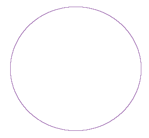

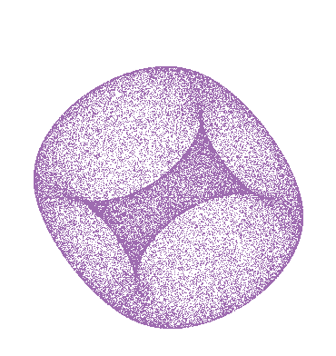

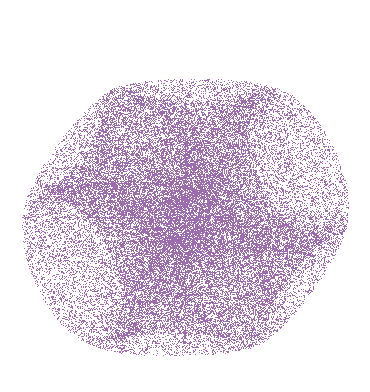

Figure 12: Flat tori in 2-D, 4-D, and 6-D.

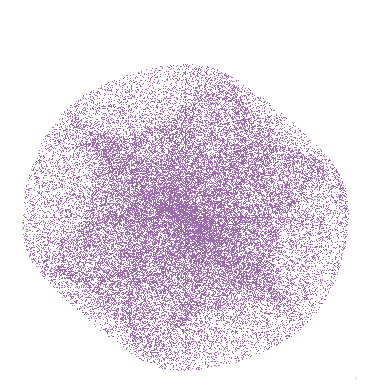

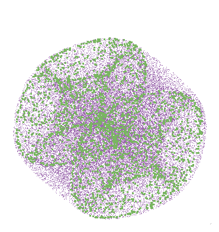

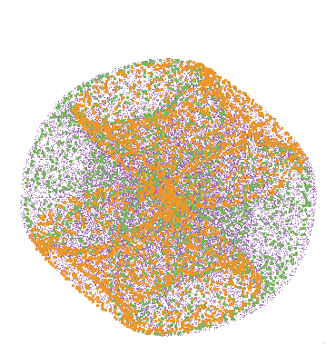

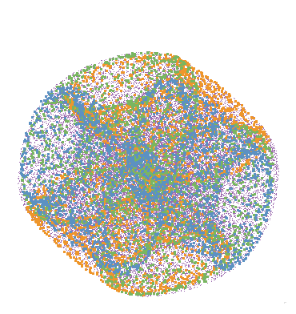

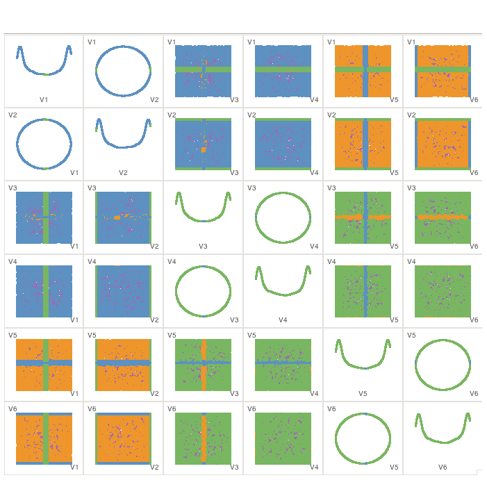

Figure 13: Views of the 6-D flat torus which illustrate its construction. The torus (top right) has its components highlighted with green, orange and blue, and the same torus is displayed as a scatterplot matrix, better revealing the construction.

### 8.3 Solid tori

These tori are all hollow. To create points in the interior of the tori one would randomly generate the radii length for each point.

## 9 Conclusion

This paper has described how [*geozoo*](https://CRAN.R-project.org/package=geozoo) generates several types of high-dimensional geometric shapes. The result is a library designed to help conceptualize objects in high-dimensional spaces. It has also led to some new geometric shape definitions.

This library, although seemingly removed from real high-dimensional data has some strong connections. Much of our data analytic methods are based in high-dimensional Euclidean space. Developing some visual insight into this space can help to understand the methods that operate in higher dimensions. Some data problems can be closely mapped to the geometric shapes. For example, ranked data showing preferences for a fixed set of objects, can be mapped to high-dimensional polytopes (Thompson 1993). Values in a sample are commonly constrained to sum to a fixed number, for example, 100%, forming compositional data. This type of data lies inside a $p$-D simplex. Good experimental designs commonly have a geometric structure (Hedayat et al. 1999). The ideas to examine boundaries of supervised classifiers described in Caragea et al. (2008) build on the geometric shapes described here.

We encourage the reader to look at the movies, and images, and download the data on the project web site, which can be accessed at http://schloerke.github.io/geozoo/. The [*geozoo*](https://CRAN.R-project.org/package=geozoo) package contains the R code to generate the geometric shapes and is available to download from CRAN (http://www.R-project.org). We especially encourage readers to experiment with creating new high-dimensional geometric shapes, or to contribute ideas and code back to this project.

## 10 Acknowledgments

This work was supported by National Science Foundation grant DMS0706949. Andreas Buja provided some helpful feedback on the work. Dianne Cook thanks the Isaac Newton Institute, Cambridge, UK for support, where she was visiting while drafting this paper.

### 10.1 CRAN packages used

geozoo, tourr, bitops

### 10.2 CRAN Task Views implied by cited packages

DynamicVisualizations

E. Abbott. *Flatland: A romance of many dimensions.* Dover Publications, 1884.

D. Asimov. *The Grand Tour: A Tool for Viewing Multidimensional Data.* SIAM Journal of Scientific; Statistical Computing,6 (1):, 1985.

P. Bourke. Geometry, Surfaces, Curves, Polyhedra. 1996.

P. Bourke. Regular Polytopes (Platonic Solids) in 4D. 2003.

P. Bourke. The Torus and Supertoroid. 1990.

A. Buja, D. Cook, D. Asimov and C. Hurley. Computational Methods for High-Dimensional Rotations in Data Visualization. In *Handbook of statistics: Data mining and visualization*, Eds C. R. Rao, E. J. Wegman and J. L. Solka pages. 391–413 2005. http://www.elsevier.com: Elsevier/North Holland.

D. Caragea, D. Cook, H. Wickham and V. Honavar. Visual Methods for Examining SVM Classifiers. In *Visual data mining: Theory, techniques and tools for visual analytics*, Eds S. Simonoff, M. Böhlen and A. Mazeika pages. 136–153 2008. Berlin: Springer-Verlag.

D. Cook. Calibrate Your Eyes to Recognize High-Dimensional Shapes from Their Low-Dimensional Projections. *Journal of Statistical Software*, 2(6): 1997. https://www.jstatsoft.org/article/view/v002i06 and http://www.public.iastate.edu/~dicook/JSS/paper/paper.html; Date accessed: 2016-07-06.

D. Cook, E. K. Lee, A. Buja, and H. Wickham. *Grand Tours, Projection Pursuit Guided Tours and Manual Controls.* In C.-H Chen; A. U W. H"ardle W. editors Handbook ofComputational Statistics (Volume III) Data Visualization Springer NewYork NY, 2007. URL http://www.springer.com.

P. Diaconis and D. Freedman. Asymptotics of Graphical Projection Pursuit. *Annals of Statistics*, 12(3): 793–815, 1984.

G. Hart. Virtual Polyhedra. 2000.

A. S. Hedayat, N. J. A. Sloane and J. Stufken, eds. *Orthogonal arrays: Theory and applications.* http://www.springer.com: Springer, 1999.

E. Martin. Flatland. 1965.

D. F. Swayne, D. Temple Lang, A. Buja and D. Cook. GGobi: Evolving from XGobi into an Extensible Framework for Interactive Data Visualization. *Journal of Computational Statistics and Data Analysis*, 43: 423–444, 2003. URL http://authors.elsevier.com/sd/article/S0167947302002864.

G. L. Thompson. Generalized permutation polytopes and exploratory graphical methods for ranked data. *The Annals of Statistics*, 21(3): 1401–1403, 1993.

G. S. Watson. *Statistics on spheres.* Wiley, 1983. URL https://books.google.com/books?id=tBjvAAAAMAAJ.

H. Wickham, D. Cook, H. Hofmann and A. Buja. tourr: An R package for exploring multivariate data with projections. *Journal of Statistical Software*, 40(2): 1–18, 2011. http://www.jstatsoft.org/v40/i02/.